# Predict Bike Sharing Demand with AutoGluon Template

## Project: Predict Bike Sharing Demand with AutoGluon

This notebook is a template with each step that you need to complete for the project.

Please fill in your code where there are explicit `?` markers in the notebook. You are welcome to add more cells and code as you see fit.

Once you have completed all the code implementations, please export your notebook as a HTML file so the reviews can view your code. Make sure you have all outputs correctly outputted.

`File-> Export Notebook As... -> Export Notebook as HTML`

There is a writeup to complete as well after all code implememtation is done. Please answer all questions and attach the necessary tables and charts. You can complete the writeup in either markdown or PDF.

Completing the code template and writeup template will cover all of the rubric points for this project.

The rubric contains "Stand Out Suggestions" for enhancing the project beyond the minimum requirements. The stand out suggestions are optional. If you decide to pursue the "stand out suggestions", you can include the code in this notebook and also discuss the results in the writeup file.

## Step 1: Create an account with Kaggle

### Create Kaggle Account and download API key

Below is example of steps to get the API username and key. Each student will have their own username and key.

1. Open account settings.

2. Scroll down to API and click Create New API Token.

3. Open up `kaggle.json` and use the username and key.


## Step 2: Download the Kaggle dataset using the kaggle python library

### Open up Sagemaker Studio and use starter template

1. Notebook should be using a `ml.t3.medium` instance (2 vCPU + 4 GiB)
2. Notebook should be using kernal: `Python 3 (MXNet 1.8 Python 3.7 CPU Optimized)`

### Install packages

```python
!pip install -U pip
!pip install -U setuptools wheel
!pip install -U "mxnet<2.0.0" bokeh==2.0.1
!pip install autogluon --no-cache-dir
# Without --no-cache-dir, smaller aws instances may have trouble installing
```

### Setup Kaggle API Key

```python
# create the .kaggle directory and an empty kaggle.json file
!sudo mkdir -p /root/.kaggle
!sudo touch /root/.kaggle/kaggle.json
!sudo chmod 600 /root/.kaggle/kaggle.json
```

```python
# Fill in your user name and key from creating the kaggle account and API token file
import json
kaggle_username = "hieunm44"
kaggle_key = "604c1fc2a9ec64466d54f7cc2bdbd60b"

# Save API token the kaggle.json file
with open("kaggle/kaggle.json", "w") as f:
    f.write(json.dumps({"username": kaggle_username, "key": kaggle_key}))
```

### Download and explore dataset

### Go to the [bike sharing demand competition](https://www.kaggle.com/c/bike-sharing-demand) and agree to the terms

```python
# Download the dataset, it will be in a .zip file so you'll need to unzip it as well.
!kaggle competitions download -c bike-sharing-demand
# If you already downloaded it you can use the -o command to overwrite the file
!unzip -o bike-sharing-demand.zip
```

```
Downloading bike-sharing-demand.zip to /home/hieu/AI/udacity-aws-ml-engineer/Course 2 Project
Archive:  bike-sharing-demand.zip
  inflating: sampleSubmission.csv
  inflating: test.csv
  inflating: train.csv
```

```python
import pandas as pd
from autogluon.tabular import TabularPredictor
```

```python
# Create the train dataset in pandas by reading the csv
# Set the parsing of the datetime column so you can use some of the `dt` features in pandas later
train = pd.read_csv('data/train.csv', parse_dates=["datetime"])
train.head()
```

|  | datetime | season | holiday | workingday | weather | temp | atemp | humidity | windspeed | casual | registered | count |
| --- | --- | --- | --- | --- | --- | --- | --- | --- | --- | --- | --- | --- |
| 0 | 2011-01-01 00:00:00 | 1 | 0 | 0 | 1 | 9.84 | 14.395 | 81 | 0.0 | 3 | 13 | 16 |
| 1 | 2011-01-01 01:00:00 | 1 | 0 | 0 | 1 | 9.02 | 13.635 | 80 | 0.0 | 8 | 32 | 40 |
| 2 | 2011-01-01 02:00:00 | 1 | 0 | 0 | 1 | 9.02 | 13.635 | 80 | 0.0 | 5 | 27 | 32 |
| 3 | 2011-01-01 03:00:00 | 1 | 0 | 0 | 1 | 9.84 | 14.395 | 75 | 0.0 | 3 | 10 | 13 |
| 4 | 2011-01-01 04:00:00 | 1 | 0 | 0 | 1 | 9.84 | 14.395 | 75 | 0.0 | 0 | 1 | 1 |

```python
# Simple output of the train dataset to view some of the min/max/varition of the dataset features.
train.describe()
```

|  | datetime | season | holiday | workingday | weather | temp | atemp | humidity | windspeed | casual | registered | count |
| --- | --- | --- | --- | --- | --- | --- | --- | --- | --- | --- | --- | --- |
| count | 10886 | 10886.000000 | 10886.000000 | 10886.000000 | 10886.000000 | 10886.00000 | 10886.000000 | 10886.000000 | 10886.000000 | 10886.000000 | 10886.000000 | 10886.000000 |
| mean | 2011-12-27 05:56:22.399411968 | 2.506614 | 0.028569 | 0.680875 | 1.418427 | 20.23086 | 23.655084 | 61.886460 | 12.799395 | 36.021955 | 155.552177 | 191.574132 |
| min | 2011-01-01 00:00:00 | 1.000000 | 0.000000 | 0.000000 | 1.000000 | 0.82000 | 0.760000 | 0.000000 | 0.000000 | 0.000000 | 0.000000 | 1.000000 |
| 25% | 2011-07-02 07:15:00 | 2.000000 | 0.000000 | 0.000000 | 1.000000 | 13.94000 | 16.665000 | 47.000000 | 7.001500 | 4.000000 | 36.000000 | 42.000000 |
| 50% | 2012-01-01 20:30:00 | 3.000000 | 0.000000 | 1.000000 | 1.000000 | 20.50000 | 24.240000 | 62.000000 | 12.998000 | 17.000000 | 118.000000 | 145.000000 |
| 75% | 2012-07-01 12:45:00 | 4.000000 | 0.000000 | 1.000000 | 2.000000 | 26.24000 | 31.060000 | 77.000000 | 16.997900 | 49.000000 | 222.000000 | 284.000000 |
| max | 2012-12-19 23:00:00 | 4.000000 | 1.000000 | 1.000000 | 4.000000 | 41.00000 | 45.455000 | 100.000000 | 56.996900 | 367.000000 | 886.000000 | 977.000000 |
| std | NaN | 1.116174 | 0.166599 | 0.466159 | 0.633839 | 7.79159 | 8.474601 | 19.245033 | 8.164537 | 49.960477 | 151.039033 | 181.144454 |

```python
# Create the test pandas dataframe in pandas by reading the csv, remember to parse the datetime!
test = pd.read_csv('data/test.csv', parse_dates=["datetime"])
test.head()
```

|  | datetime | season | holiday | workingday | weather | temp | atemp | humidity | windspeed |
| --- | --- | --- | --- | --- | --- | --- | --- | --- | --- |
| 0 | 2011-01-20 00:00:00 | 1 | 0 | 1 | 1 | 10.66 | 11.365 | 56 | 26.0027 |
| 1 | 2011-01-20 01:00:00 | 1 | 0 | 1 | 1 | 10.66 | 13.635 | 56 | 0.0000 |
| 2 | 2011-01-20 02:00:00 | 1 | 0 | 1 | 1 | 10.66 | 13.635 | 56 | 0.0000 |
| 3 | 2011-01-20 03:00:00 | 1 | 0 | 1 | 1 | 10.66 | 12.880 | 56 | 11.0014 |
| 4 | 2011-01-20 04:00:00 | 1 | 0 | 1 | 1 | 10.66 | 12.880 | 56 | 11.0014 |

```python
# Same thing as train and test dataset
submission = pd.read_csv('data/sampleSubmission.csv', parse_dates=["datetime"])
submission.head()
```

|  | datetime | count |
| --- | --- | --- |
| 0 | 2011-01-20 00:00:00 | 0 |
| 1 | 2011-01-20 01:00:00 | 0 |
| 2 | 2011-01-20 02:00:00 | 0 |
| 3 | 2011-01-20 03:00:00 | 0 |
| 4 | 2011-01-20 04:00:00 | 0 |

## Step 3: Train a model using AutoGluon’s Tabular Prediction

Requirements:

- We are predicting `count`, so it is the label we are setting.
- Ignore `casual` and `registered` columns as they are also not present in the test dataset.
- Use the `root_mean_squared_error` as the metric to use for evaluation.
- Set a time limit of 10 minutes (600 seconds).
- Use the preset `best_quality` to focus on creating the best model.

```python
predictor = TabularPredictor(
    label="count",
    problem_type="regression",
    eval_metric="root_mean_squared_error",
    learner_kwargs={"ignored_columns":["casual", "registered"]}
).fit(
    train,
    time_limit=600,
    presets="best_quality")
```

[output not shown]

[output cut: 32 more lines]

[output not shown]

[output not shown]

[output not shown]

[output not shown]

[output not shown]

[output not shown]

[output not shown]

[output cut: 141 more lines]

[output not shown]

### Review AutoGluon's training run with ranking of models that did the best.

```python
predictor.fit_summary()
```

```
*** Summary of fit() ***
Estimated performance of each model:
                     model   score_val              eval_metric  pred_time_val    fit_time  pred_time_val_marginal  fit_time_marginal  stack_level  can_infer  fit_order
0      WeightedEnsemble_L3  -50.512971  root_mean_squared_error      11.277783  317.285677                0.000524           0.034254            3       True         20
1   NeuralNetFastAI_BAG_L2  -51.682279  root_mean_squared_error      10.049410  300.402349                0.538653          39.347199            2       True         18
2   RandomForestMSE_BAG_L2  -53.288009  root_mean_squared_error      10.122335  274.697823                0.611578          13.642674            2       True         15
3     ExtraTreesMSE_BAG_L2  -54.161818  root_mean_squared_error      10.127027  264.261549                0.616270           3.206400            2       True         17
4          LightGBM_BAG_L2  -55.174616  root_mean_squared_error       9.754811  267.846767                0.244054           6.791618            2       True         14
5           XGBoost_BAG_L2  -55.319566  root_mean_squared_error       9.644580  265.858336                0.133823           4.803186            2       True         19
6          CatBoost_BAG_L2  -55.636515  root_mean_squared_error       9.563524  288.539305                0.052767          27.484156            2       True         16
7        LightGBMXT_BAG_L2  -60.132401  root_mean_squared_error      12.424361  287.517174                2.913604          26.462025            2       True         13
8    KNeighborsDist_BAG_L1  -84.125061  root_mean_squared_error       0.050010    0.024725                0.050010           0.024725            1       True          2
9      WeightedEnsemble_L2  -84.125061  root_mean_squared_error       0.050900    0.058505                0.000890           0.033780            2       True         12
10   KNeighborsUnif_BAG_L1 -101.546199  root_mean_squared_error       0.047425    0.036090                0.047425           0.036090            1       True          1
11  RandomForestMSE_BAG_L1 -116.548359  root_mean_squared_error       0.576130    3.781003                0.576130           3.781003            1       True          5
12    ExtraTreesMSE_BAG_L1 -124.600676  root_mean_squared_error       0.449388    1.435299                0.449388           1.435299            1       True          7
13         CatBoost_BAG_L1 -130.461205  root_mean_squared_error       0.055790  105.661549                0.055790         105.661549            1       True          6
14         LightGBM_BAG_L1 -131.054162  root_mean_squared_error       1.238586   12.242540                1.238586          12.242540            1       True          4
15       LightGBMXT_BAG_L1 -131.460909  root_mean_squared_error       5.792656   40.741728                5.792656          40.741728            1       True          3
16          XGBoost_BAG_L1 -131.893935  root_mean_squared_error       0.392545    7.302768                0.392545           7.302768            1       True          9
17    LightGBMLarge_BAG_L1 -133.466868  root_mean_squared_error       0.126346    3.754001                0.126346           3.754001            1       True         11
18  NeuralNetFastAI_BAG_L1 -136.227786  root_mean_squared_error       0.376690   38.991699                0.376690          38.991699            1       True          8
19   NeuralNetTorch_BAG_L1 -141.481324  root_mean_squared_error       0.405192   47.083747                0.405192          47.083747            1       True         10
Number of models trained: 20
Types of models trained:
{'StackerEnsembleModel_CatBoost', 'StackerEnsembleModel_TabularNeuralNetTorch', 'WeightedEnsembleModel', 'StackerEnsembleModel_XGBoost', 'StackerEnsembleModel_LGB', 'StackerEnsembleModel_XT', 'StackerEnsembleModel_NNFastAiTabular', 'StackerEnsembleModel_KNN', 'StackerEnsembleModel_RF'}
Bagging used: True  (with 8 folds)
Multi-layer stack-ensembling used: True  (with 3 levels)
Feature Metadata (Processed):
(raw dtype, special dtypes):
('float', [])                : 3 | ['temp', 'atemp', 'windspeed']
('int', [])                  : 3 | ['season', 'weather', 'humidity']
('int', ['bool'])            : 2 | ['holiday', 'workingday']
('int', ['datetime_as_int']) : 5 | ['datetime', 'datetime.year', 'datetime.month', 'datetime.day', 'datetime.dayofweek']
*** End of fit() summary ***
```

[output not shown]

[output cut: 199 more lines]

[output not shown]

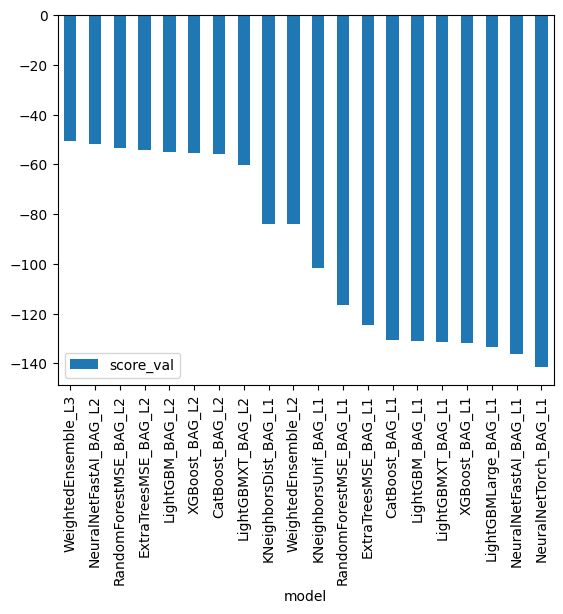

```python
predictor.leaderboard(silent=True).plot(kind="bar", x="model", y="score_val");
```

### Create predictions from test dataset

```python
predictions = predictor.predict(test)
predictions.head()
```

```
0    24.629593
1    39.991585
2    44.516708
3    47.933403
4    50.334831
Name: count, dtype: float32
```

#### NOTE: Kaggle will reject the submission if we don't set everything to be > 0.

```python
# Describe the `predictions` series to see if there are any negative values
predictions.describe()
```

```
count    6493.000000
mean      100.057823
std        88.559029
min         1.566241
25%        22.191525
50%        68.630798
75%       165.988098
max       350.166199
Name: count, dtype: float64
```

```python
# How many negative values do we have?
negative_values_count = 0

for value in predictions:
    if value < 0:
        negative_values_count += 1

print("Negative values in predictions: ", negative_values_count)
```

```
Negative values in predictions:  0
```

```python
# Set them to zero
if negative_values_count > 0:
    predictions[predictions < 0] = 0
```

### Set predictions to submission dataframe, save, and submit

```python
submission["count"] = predictions
submission.to_csv("data/submission.csv", index=False)
```

```python
!kaggle competitions submit -c bike-sharing-demand -f submission.csv -m "first raw submission"
```

```
Successfully submitted to Bike Sharing Demand
```

#### View submission via the command line or in the web browser under the competition's page - `My Submissions`

```python
!kaggle competitions submissions -c bike-sharing-demand | tail -n +1 | head -n 6
```

```
fileName        date                 description           status    publicScore  privateScore
--------------  -------------------  --------------------  --------  -----------  ------------
submission.csv  2024-08-24 22:23:31  first raw submission  complete  1.80362      1.80362
```

#### Initial score of `1.80362`

## Step 4: Exploratory Data Analysis and Creating an additional feature

- Any additional feature will do, but a great suggestion would be to separate out the datetime into hour, day, or month parts.

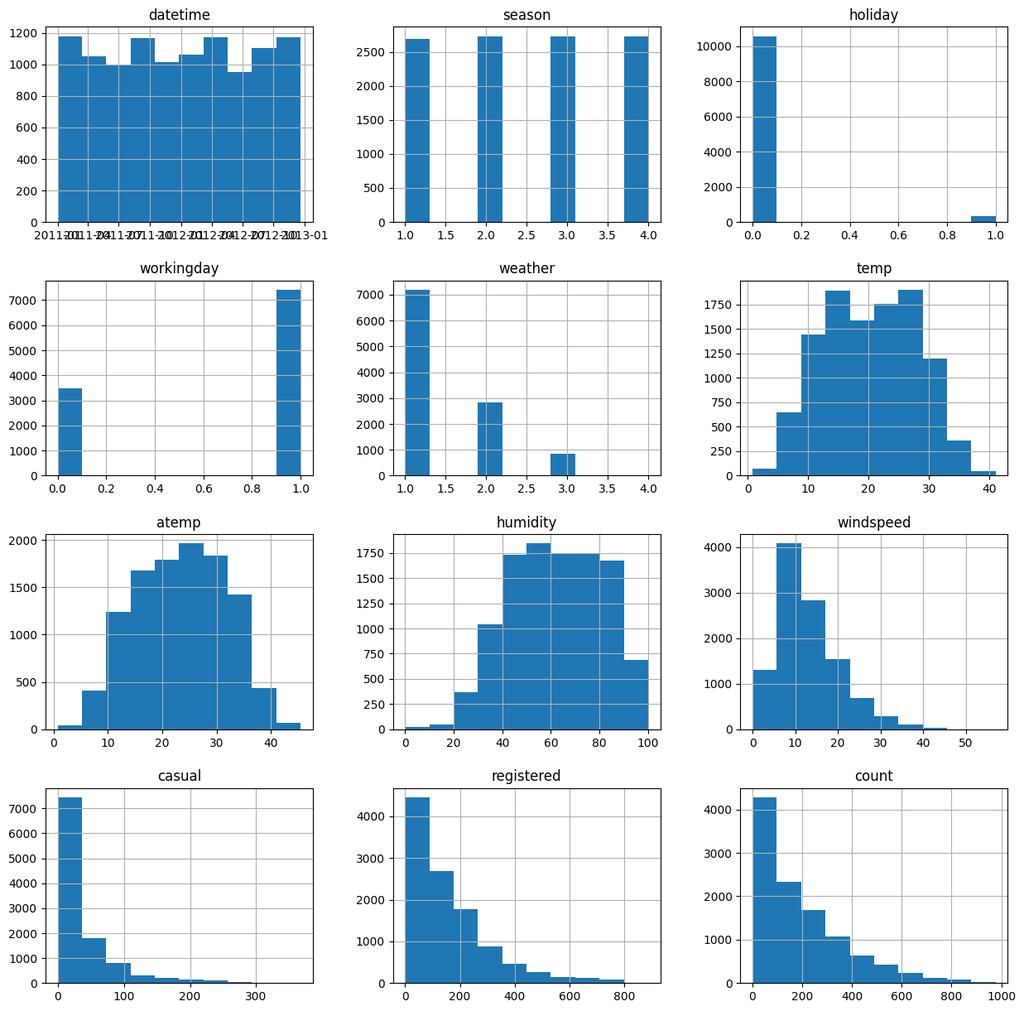

```python
# Create a histogram of all features to show the distribution of each one relative to the data. This is part of the exploritory data analysis
train.hist(figsize=(15, 15));
```

```python
# create a new feature
train['year'] = train.datetime.dt.year
train['month'] = train.datetime.dt.month
train['day'] = train.datetime.dt.day
train['hour'] = train.datetime.dt.hour
train['dayofweek'] = train.datetime.dt.dayofweek

test['year'] = test.datetime.dt.year
test['month'] = test.datetime.dt.month
test['day'] = test.datetime.dt.day
test['hour'] = test.datetime.dt.hour
test['dayofweek'] = test.datetime.dt.dayofweek
```

## Make category types for these so models know they are not just numbers

- AutoGluon originally sees these as ints, but in reality they are int representations of a category.
- Setting the dtype to category will classify these as categories in AutoGluon.

```python
train["season"] = train["season"].astype('category')
train["weather"] = train["weather"].astype('category')
test["season"] = test["season"].astype('category')
test["weather"] = test["weather"].astype('category')
```

```python
# View are new feature
train.head()
```

|  | datetime | season | holiday | workingday | weather | temp | atemp | humidity | windspeed | casual | registered | count | year | month | day | hour | dayofweek |
| --- | --- | --- | --- | --- | --- | --- | --- | --- | --- | --- | --- | --- | --- | --- | --- | --- | --- |
| 0 | 2011-01-01 00:00:00 | 1 | 0 | 0 | 1 | 9.84 | 14.395 | 81 | 0.0 | 3 | 13 | 16 | 2011 | 1 | 1 | 0 | 5 |
| 1 | 2011-01-01 01:00:00 | 1 | 0 | 0 | 1 | 9.02 | 13.635 | 80 | 0.0 | 8 | 32 | 40 | 2011 | 1 | 1 | 1 | 5 |
| 2 | 2011-01-01 02:00:00 | 1 | 0 | 0 | 1 | 9.02 | 13.635 | 80 | 0.0 | 5 | 27 | 32 | 2011 | 1 | 1 | 2 | 5 |
| 3 | 2011-01-01 03:00:00 | 1 | 0 | 0 | 1 | 9.84 | 14.395 | 75 | 0.0 | 3 | 10 | 13 | 2011 | 1 | 1 | 3 | 5 |
| 4 | 2011-01-01 04:00:00 | 1 | 0 | 0 | 1 | 9.84 | 14.395 | 75 | 0.0 | 0 | 1 | 1 | 2011 | 1 | 1 | 4 | 5 |

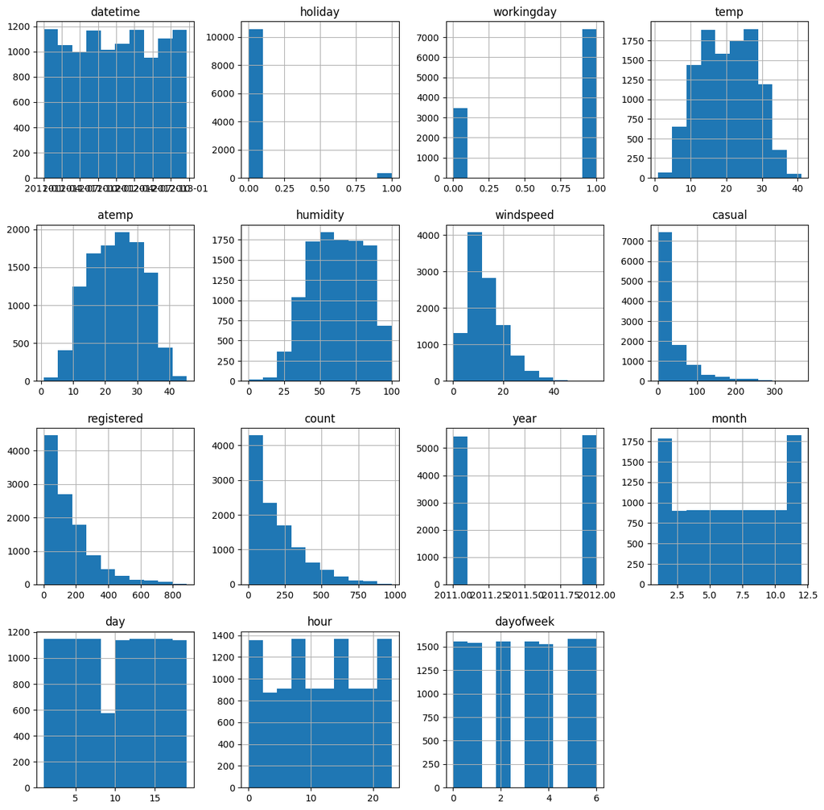

```python
# View histogram of all features again now with the hour feature
train.hist(figsize=(15, 15));
```

## Step 5: Rerun the model with the same settings as before, just with more features

```python
predictor_new_features = TabularPredictor(
    label="count",
    problem_type="regression",
    eval_metric="root_mean_squared_error",
    learner_kwargs={"ignored_columns":["casual", "registered"]}
).fit(
    train,
    time_limit=600,
    presets="best_quality")
```

[output not shown]

[output cut: 118 more lines]

[output not shown]

```python
predictor_new_features.fit_summary()
```

```
*** Summary of fit() ***
Estimated performance of each model:
                     model   score_val              eval_metric  pred_time_val    fit_time  pred_time_val_marginal  fit_time_marginal  stack_level  can_infer  fit_order
0      WeightedEnsemble_L3  -30.063542  root_mean_squared_error      19.645488  359.576646                0.001631           0.078464            3       True         16
1          CatBoost_BAG_L2  -30.457185  root_mean_squared_error      18.707634  319.948996                0.077542          48.950191            2       True         13
2          LightGBM_BAG_L2  -30.635246  root_mean_squared_error      18.937768  279.941772                0.307676           8.942967            2       True         11
3   NeuralNetFastAI_BAG_L2  -31.003282  root_mean_squared_error      19.258640  301.605024                0.628547          30.606219            2       True         15
4        LightGBMXT_BAG_L2  -31.264794  root_mean_squared_error      19.571409  283.598445                0.941317          12.599640            2       True         10
5     ExtraTreesMSE_BAG_L2  -31.457461  root_mean_squared_error      19.353413  275.252296                0.723320           4.253491            2       True         14
6   RandomForestMSE_BAG_L2  -31.687273  root_mean_squared_error      19.374440  286.135133                0.744347          15.136328            2       True         12
7      WeightedEnsemble_L2  -32.091283  root_mean_squared_error      16.964555  243.410933                0.002061           0.060610            2       True          9
8          CatBoost_BAG_L1  -33.362490  root_mean_squared_error       0.299981  141.059924                0.299981         141.059924            1       True          6
9          LightGBM_BAG_L1  -33.917339  root_mean_squared_error       2.828284   28.307939                2.828284          28.307939            1       True          4
10       LightGBMXT_BAG_L1  -34.558198  root_mean_squared_error      12.976152   68.781054               12.976152          68.781054            1       True          3
11    ExtraTreesMSE_BAG_L1  -38.345299  root_mean_squared_error       0.911435    3.399717                0.911435           3.399717            1       True          7
12  RandomForestMSE_BAG_L1  -38.457708  root_mean_squared_error       0.806859    5.160549                0.806859           5.160549            1       True          5
13  NeuralNetFastAI_BAG_L1  -75.985964  root_mean_squared_error       0.685142   24.203437                0.685142          24.203437            1       True          8
14   KNeighborsDist_BAG_L1  -84.125061  root_mean_squared_error       0.051219    0.040857                0.051219           0.040857            1       True          2
15   KNeighborsUnif_BAG_L1 -101.546199  root_mean_squared_error       0.071023    0.045328                0.071023           0.045328            1       True          1
Number of models trained: 16
Types of models trained:
{'StackerEnsembleModel_CatBoost', 'WeightedEnsembleModel', 'StackerEnsembleModel_LGB', 'StackerEnsembleModel_XT', 'StackerEnsembleModel_NNFastAiTabular', 'StackerEnsembleModel_KNN', 'StackerEnsembleModel_RF'}
Bagging used: True  (with 8 folds)
Multi-layer stack-ensembling used: True  (with 3 levels)
Feature Metadata (Processed):
(raw dtype, special dtypes):
('category', [])             : 2 | ['season', 'weather']
('float', [])                : 3 | ['temp', 'atemp', 'windspeed']
('int', [])                  : 5 | ['humidity', 'month', 'day', 'hour', 'dayofweek']
('int', ['bool'])            : 3 | ['holiday', 'workingday', 'year']
('int', ['datetime_as_int']) : 2 | ['datetime', 'datetime.year']
*** End of fit() summary ***
```

[output not shown]

[output cut: 151 more lines]

[output not shown]

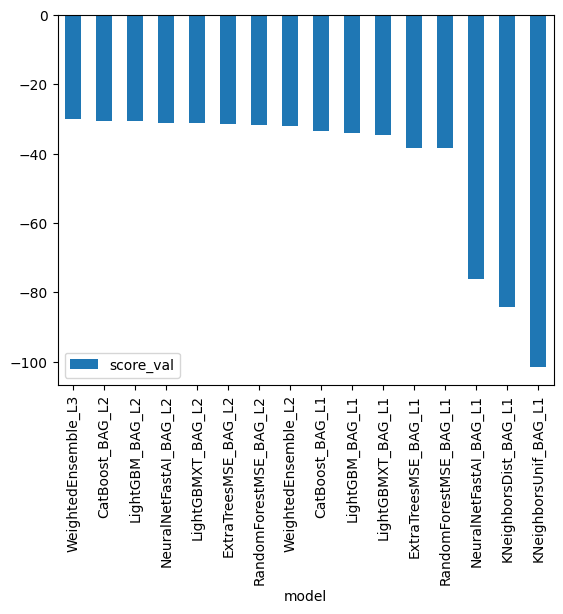

```python
predictor_new_features.leaderboard(silent=True).plot(kind="bar", x="model", y="score_val");
```

```python
# Remember to set all negative values to zero
predictions_new_features = predictor_new_features.predict(test)

negative_values_count = 0

for value in predictions_new_features:
    if value < 0:
        negative_values_count += 1

print(negative_values_count)

if negative_values_count > 0:
    predictions_new_features.iloc[predictions_new_features < 0] = 0
```

```
0
```

```python
# Same submitting predictions
submission_new_features = pd.read_csv('data/sampleSubmission.csv')
submission_new_features["count"] = predictions_new_features
submission_new_features.to_csv("data/submission_new_features.csv", index=False)
```

```python
!kaggle competitions submit -c bike-sharing-demand -f submission_new_features.csv -m "new features"
```

```
Successfully submitted to Bike Sharing Demand
```

```python
!kaggle competitions submissions -c bike-sharing-demand | tail -n +1 | head -n 6
```

```
fileName                     date                 description           status    publicScore  privateScore
---------------------------  -------------------  --------------------  --------  -----------  ------------
submission_new_features.csv  2024-08-24 22:39:54  new features          complete  0.68146      0.68146
submission.csv               2024-08-24 22:23:31  first raw submission  complete  1.80362      1.80362
```

#### New Score of `0.68146`

## Step 6: Hyper parameter optimization

- There are many options for hyper parameter optimization.
- Options are to change the AutoGluon higher level parameters or the individual model hyperparameters.
- The hyperparameters of the models themselves that are in AutoGluon. Those need the `hyperparameter` and `hyperparameter_tune_kwargs` arguments.

```python
import autogluon as ag


nn_options = {
    'num_epochs': 10,
    'learning_rate': ag.common.space.Real(1e-4, 1e-2, default=5e-3, log=True),
    'activation': ag.common.space.Categorical('relu', 'softrelu', 'tanh'),
    'dropout_prob': ag.common.space.Real(0.0, 0.5, default=0.1),
}


gbm_options = {
    'num_boost_round': 100,
    'num_leaves': ag.common.space.Int(lower=20, upper=60, default=30),
}


hyperparameters = {
                   'GBM': gbm_options,
                   'NN_TORCH': nn_options,
                  }


num_trials = 6
search_strategy = 'random'
num_folds = 12


hyperparameter_tune_kwargs = {  # HPO is not performed unless hyperparameter_tune_kwargs is specified
    'num_trials': num_trials,
    'scheduler' : 'local',
    'searcher': search_strategy,
}

predictor_new_hpo = TabularPredictor(
    label="count",
    problem_type="regression",
    eval_metric="root_mean_squared_error",
    learner_kwargs={"ignored_columns":["casual", "registered"]}
).fit(
    train,
    time_limit=600,
    presets="best_quality",
    hyperparameters=hyperparameters,
    hyperparameter_tune_kwargs=hyperparameter_tune_kwargs
)
```

[output not shown]

```python
predictor_new_hpo.fit_summary()
```

```
*** Summary of fit() ***
Estimated performance of each model:
                                model   score_val              eval_metric  pred_time_val    fit_time  pred_time_val_marginal  fit_time_marginal  stack_level  can_infer  fit_order
0                 WeightedEnsemble_L3  -36.044133  root_mean_squared_error       6.860707  355.640311                0.000816           0.026617            3       True         21
1                  LightGBM_BAG_L2/T2  -36.312887  root_mean_squared_error       5.568492  265.381047                0.123353           6.509978            2       True         12
2                  LightGBM_BAG_L2/T3  -36.488632  root_mean_squared_error       5.613568  265.824008                0.168430           6.952938            2       True         13
3                  LightGBM_BAG_L2/T1  -36.499697  root_mean_squared_error       5.588588  265.083895                0.143450           6.212826            2       True         11
4                  LightGBM_BAG_L2/T5  -37.170676  root_mean_squared_error       5.603505  266.074597                0.158367           7.203528            2       True         15
5                 WeightedEnsemble_L2  -38.250776  root_mean_squared_error       0.850207   49.559538                0.000774           0.053938            2       True         10
6   NeuralNetTorch_BAG_L2/62997_00000  -38.327557  root_mean_squared_error       6.166423  297.477599                0.721285          38.606530            2       True         17
7                  LightGBM_BAG_L1/T3  -38.540051  root_mean_squared_error       0.154604    6.358768                0.154604           6.358768            1       True          3
8   NeuralNetTorch_BAG_L2/62997_00001  -40.044102  root_mean_squared_error       5.846823  303.544249                0.401685          44.673179            2       True         18
9                  LightGBM_BAG_L1/T2  -40.462094  root_mean_squared_error       0.129530    5.884174                0.129530           5.884174            1       True          2
10  NeuralNetTorch_BAG_L2/62997_00003  -41.034162  root_mean_squared_error       7.706222  318.487769                2.261084          59.616700            2       True         20
11                 LightGBM_BAG_L1/T1  -41.318184  root_mean_squared_error       0.129655    5.693618                0.129655           5.693618            1       True          1
12                 LightGBM_BAG_L1/T5  -44.437463  root_mean_squared_error       0.140749    7.102072                0.140749           7.102072            1       True          5
13  NeuralNetTorch_BAG_L2/62997_00002  -49.103254  root_mean_squared_error       6.451431  307.253947                1.006293          48.382877            2       True         19
14  NeuralNetTorch_BAG_L1/f6d56_00000  -53.339407  root_mean_squared_error       0.565299   37.262658                0.565299          37.262658            1       True          7
15  NeuralNetTorch_BAG_L1/f6d56_00001  -70.241139  root_mean_squared_error       2.027695  102.875815                2.027695         102.875815            1       True          8
16                 LightGBM_BAG_L2/T6  -99.851367  root_mean_squared_error       5.578957  266.282010                0.133819           7.410941            2       True         16
17                 LightGBM_BAG_L2/T4 -103.014412  root_mean_squared_error       5.558020  264.789918                0.112882           5.918849            2       True         14
18                 LightGBM_BAG_L1/T6 -110.853669  root_mean_squared_error       0.100902    6.115920                0.100902           6.115920            1       True          6
19                 LightGBM_BAG_L1/T4 -125.286618  root_mean_squared_error       0.114986    6.059105                0.114986           6.059105            1       True          4
20  NeuralNetTorch_BAG_L1/f6d56_00002 -133.235296  root_mean_squared_error       2.081717   81.518939                2.081717          81.518939            1       True          9
Number of models trained: 21
Types of models trained:
{'StackerEnsembleModel_TabularNeuralNetTorch', 'StackerEnsembleModel_LGB', 'WeightedEnsembleModel'}
Bagging used: True  (with 8 folds)
Multi-layer stack-ensembling used: True  (with 3 levels)
Feature Metadata (Processed):
(raw dtype, special dtypes):
('category', [])             : 2 | ['season', 'weather']
('float', [])                : 3 | ['temp', 'atemp', 'windspeed']
('int', [])                  : 5 | ['humidity', 'month', 'day', 'hour', 'dayofweek']
('int', ['bool'])            : 3 | ['holiday', 'workingday', 'year']
('int', ['datetime_as_int']) : 2 | ['datetime', 'datetime.year']
*** End of fit() summary ***
```

[output not shown]

[output cut: 212 more lines]

[output not shown]

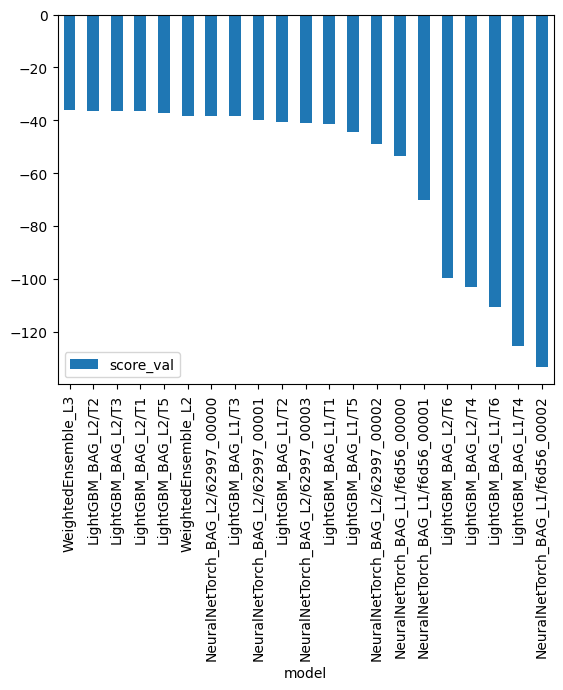

```python
predictor_new_hpo.leaderboard(silent=True).plot(kind="bar", x="model", y="score_val");
```

```python
# Remember to set all negative values to zero
predictions_new_hypo = predictor_new_hpo.predict(test)
predictions_new_hypo

negative_values_count = 0

for value in predictions_new_hypo:
    if value < 0:
        negative_values_count += 1

print(negative_values_count)

if negative_values_count > 0:
    predictor_new_hpo.iloc[predictor_new_hpo < 0] = 0
```

```
0
```

```python
# Same submitting predictions
submission_new_hpo = pd.read_csv('data/sampleSubmission.csv')
submission_new_hpo["count"] = predictions_new_hypo
submission_new_hpo.to_csv("data/submission_new_hpo.csv", index=False)
```

```python
!kaggle competitions submit -c bike-sharing-demand -f submission_new_hpo.csv -m "new features with hyperparameters"
```

```
Successfully submitted to Bike Sharing Demand
```

```python
!kaggle competitions submissions -c bike-sharing-demand | tail -n +1 | head -n 6
```

```
fileName                     date                 description                        status    publicScore  privateScore
---------------------------  -------------------  ---------------------------------  --------  -----------  ------------
submission_new_hpo.csv       2024-08-24 23:01:40  new features with hyperparameters  complete  0.47593      0.47593
submission_new_features.csv  2024-08-24 22:39:54  new features                       complete  0.68146      0.68146
submission.csv               2024-08-24 22:23:31  first raw submission               complete  1.80362      1.80362
```